# Jaehyung Andy Lee

# Summary

**Last Updated Time**: 2022-05-03 21:26:12

Coding in **Python, R, and SQL** is my passion and has enabled me to [automate numerous redundant daily tasks](https://github.com/aLin-96/notion_automation), perform statistical analyses for various projects, and even create [personal websites](https://alin-96.github.io/).

As a graduating Senior at SUNY Geneseo with a **Mathematics major** and Data Analytics concentration, I have honed strong skills in **data analysis, data visualization, and machine learning**.

I am eager to apply my programming and analytical skills to a growing company and am actively seeking a challenging role as a Data Analyst or Data Scientist.

Previously, I worked as a Data Manager at a hospitality company in Korea, where I have helped increase the weekly revenue by over 3000% by analyzing the market and creating python algorithms.

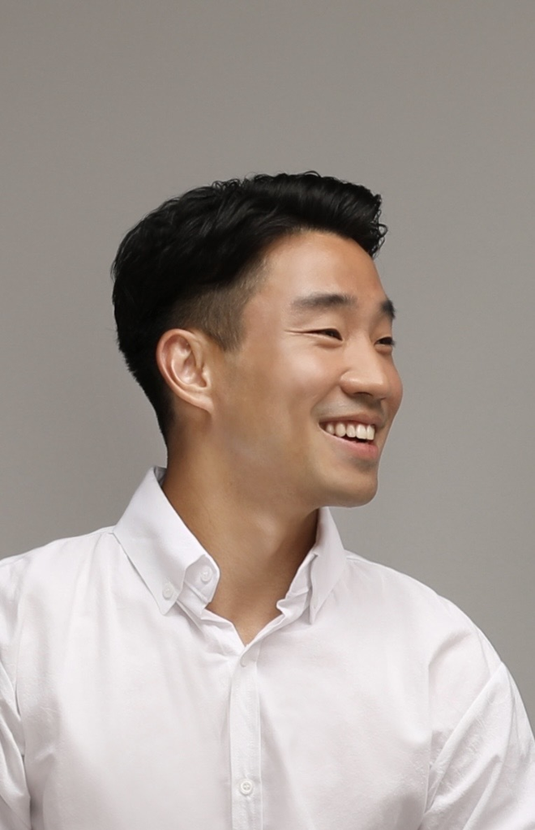

Currently, I am a part-time Data Analytics Tutor at SUNY Geneseo teaching students the fundamentals of Data Analytics and introducing machine learning basics.

My **Core Technical Skills** include:

- SQL, Python, R, Tableau
- Machine Learning
- Data Wrangling/ Manipulation
- Data Modeling
- Data Visualization

My goal is to join a company that provides various learning experiences and personal growth. A curious company that constantly challenges itself to find a better and faster solution would be ideal.

Don’t hesitate to get in touch with me via email or connect with me on LinkedIn to find out how I can add value to your team.

**Websites**:

[Portfolio](https://www.andyleeproject.com/)

[Projects](https://alin-96.github.io/)

[Github](https://github.com/aLin-96)

[LinkedIn](https://www.linkedin.com/in/jaehyungandylee/)

Resume

Contact Information: anddy0622@gmail.com

# Current Position

| 2021 — present | Data Analytics Tutor [School of Business, SUNY Geneseo](https://www.geneseo.edu/business/) |
| --- | --- |

# Education

| 2020 — 2022 | B.A. in Mathematics, SUNY Geneseo |
| --- | --- |
| 2018 — 2020 | Korean Military, JSA Panmunjom, South Korea |
| 2015 — 2017 | B.A. in Mathematics, SUNY Geneseo |

# Work Experience

| 2021 | Data Manager Jeju, South Korea In charge of business operations, marketing, and data management. |
| --- | --- |
| 2018 | Translator/ Sergeant Panmunjom Served approximately 2 years at JSA, Panmunjom |

# Skills

|  | Programming Languages: R, Python, SQL, Tableau, HTML, and CSS |
| --- | --- |
|  | Speaking Languages: Fluent in Enlighs and Korean |
|  | Soft Skills: Commuication, Problem-solving, Creativity, and Attention to detail |